# INFO 371 Lab 7: Neural Networks

#### Instructions

Please submit your completed lab notebook by the deadline. Working together is fun and useful but you must submit your own work. Discussing the solutions and problems with your instructors and classmates is completely fine. However, **do not** copy and paste their solution(s). Remember - your code/work should not appear (directly or indirectly) on any one else's machine and vice versa.

#### Introduction

For this lab, you will be predicting the colors in a color spiral using neural networks. Your task will be to design and test the architecture of several multi-layered neural networks.

```python
#### this cell contains a function for you to use. Do not delete, edit, or modify.
import numpy as np
import matplotlib.pyplot as plt

def dbPlot(m, X, y, nGrid=100):
    """
    m: fitted model (perceptron or any other)
    X: design matrix, used to plot dots
    y: outcome vector, used to color dots
    """
    ## Predict: take this code as black box
    range1 = np.linspace(X[:,0].min(), X[:,0].max(), nGrid)
    range2 = np.linspace(X[:,1].min(), X[:,1].max(), nGrid)
    (xx1, xx2) = np.meshgrid(range1, range2)
    Xgrid = np.column_stack((xx1.ravel(), xx2.ravel()))
    yhat = m.predict(Xgrid)
    plt.figure(figsize=(10,10))
    ## plot the predicted values on grid as an image
    plt.imshow(yhat.reshape((nGrid,nGrid)), alpha=0.3, extent=[xx1.min(), xx1.max(), xx2.min(), xx2.max()],
               origin= 'lower', aspect= 'auto')
    # add the actual values
    plt.scatter(X[:,0], X[:,1], c=y, s=20, alpha=0.5, edgecolor="k")
    plt.xlabel("X1")
    plt.ylabel("X2")
    plt.show()

####
```

```python
import pandas as pd
import seaborn as sns
```

### Part 1: Data preparation

To start, let's prepare the data. This will have several steps.

#### 1. Load the data.

To begin, load the data in the "spiral-1000.csv" file. Note that the data may not be comma-separated and you'll have to use the appropriate separator. What are the dimensions of the data?

```python
data = pd.read_csv('spiral-1000.csv', sep='\t')
data.shape
```

```
(1000, 5)
```

The data has 1,000 rows and 5 columns

#### 2. Filter the data

For our purposes, we're only interested in 3 columns from the data: `x`, `y`, and `color`. Filter the data to these three columns. Plot the data showing `x` along the x-axis, `y` along the y-axis, and `color` as the color of the point. What does your plot look like? How many colors are there?

```python
data = data[['x', 'y', 'color']]
data.head()
```

|  | x | y | color |
| --- | --- | --- | --- |
| 0 | -1.832941 | 0.334209 | 2 |
| 1 | 0.528780 | 0.727596 | 3 |
| 2 | -1.742425 | 1.242895 | 1 |
| 3 | 0.969640 | -0.387201 | 1 |
| 4 | -0.932878 | -1.155260 | 1 |

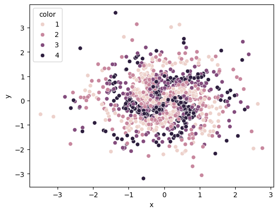

```python
_ = sns.scatterplot(data = data, x='x', y='y', hue='color')
```

#### 3. Train-test split

Create a 80/20 train-test split of the data. Use your `x` and `y` columns in your design matrix (i.e. X; inputs) and `color` as your y (i.e. output). What are the shapes of your training and test data?

```python
from sklearn.model_selection import train_test_split
from sklearn.metrics import accuracy_score
```

```python
X = data[['x', 'y']]
y = data['color']
```

```python
X_train, X_test, y_train, y_test = train_test_split(X, y, train_size=0.8, random_state=11)
X_train.shape, X_test.shape
```

```
((800, 2), (200, 2))
```

### Part 2: Modeling

Next, we'll fit a neural network to the data.

#### 1. Fit a MLP

Fit a multi-layered perceptron to the data. Use a 10x10 architecture with 2000 maximum iterations. What is your training and test accuracy?

```python
from sklearn.neural_network import MLPClassifier
```

```python
clf_mlp = MLPClassifier(hidden_layer_sizes=(10, 10), max_iter=2000, random_state = 11)
```

```python
clf_mlp.fit(X_train, y_train)
```

```
MLPClassifier(hidden_layer_sizes=(10, 10), max_iter=2000, random_state=11)
```

```python
preds_train_mlp = clf_mlp.predict(X_train)
accuracy_score(y_train, preds_train_mlp)
```

```
0.47625
```

```python
preds_test_mlp = clf_mlp.predict(X_test)
accuracy_score(y_test, preds_test_mlp)
```

```
0.38
```

The accuracy of the training data is 0.47625 and the accuracy of the test data is 0.38

#### 2. Plot the decision boundaries

Use the `dbPlot` function from above to plot the decision boundary for the model you created. The function takes in three inputs: the fitted model, the x values, and the y values from the data (i.e. NOT the inputs and outputs). What can you say about the decision boundaries?

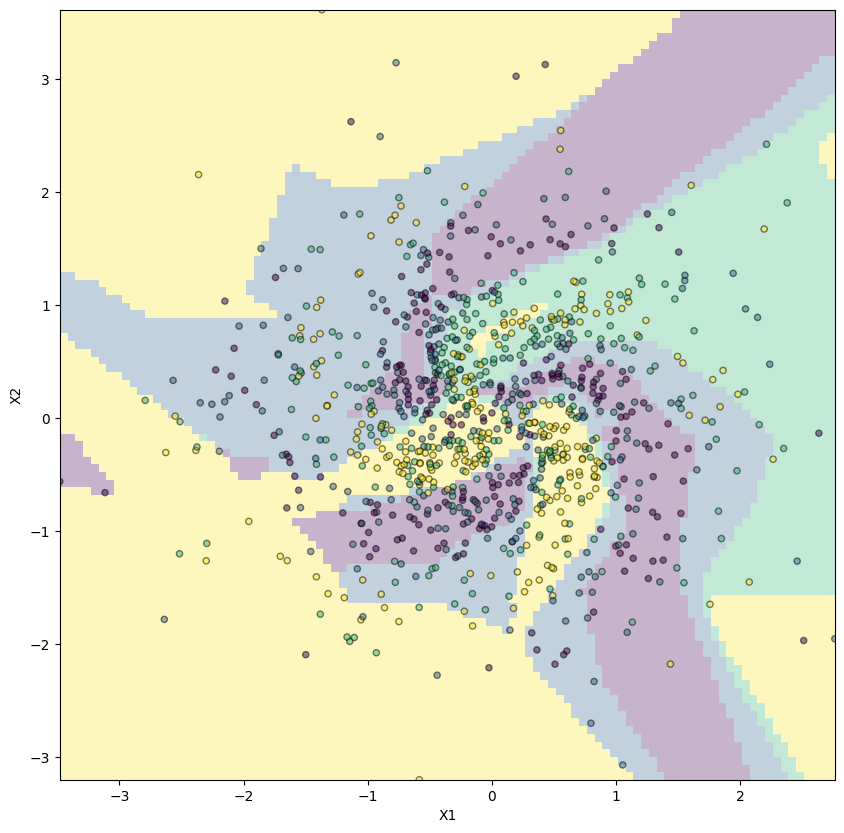

```python
_ = dbPlot(clf_mlp, X.values, y.values)
```

#### 3. Model parameters

How many coefficents do you have in your model? How many intercepts/biases? How are these organized with respect to the number and size of the layers you specified when training the model?

Hint: the `intercepts_` and `coefs_` attributes of your model may be helpful.

```python
clf_mlp.intercepts_ # Number of nodes in each layer
```

```
[array([ 1.11557964,  0.6851448 , -0.51629884, -0.16418392, -1.27568172,
        -0.77647837,  0.56100626,  0.9741626 , -0.89774781, -0.52205732]),
 array([ 1.22715379,  0.44558635,  0.68525873,  0.23500542,  0.9498271 ,
        -0.30605497,  0.53248223, -0.63309099, -0.16971365,  0.18977478]),
 array([-0.36490207,  0.77980976,  0.29429431,  0.06988626])]
```

```python
[coef.size for coef in clf_mlp.coefs_] # Number of nodes in the previous layer * number of nodes in the current layer
```

```
[20, 100, 40]
```

```python
[coef.shape[0] for coef in clf_mlp.coefs_] # started with 2 input nodes, then 2 hidden layers with 10 nodes each
```

```
[2, 10, 10]
```

```python
[coef.shape[1] for coef in clf_mlp.coefs_] # Finally, we have 4 output nodes
```

```
[10, 10, 4]
```

We have (2 * 10) + (10 * 10) + (10 * 4) = 160 coefficients in our model

### Part 3: Improve your model

Next, we'll try to improve the fit of the model

#### 1. Optimize network design

Next, use 3-fold cross validation (you're welcome to use a higher K value) to optimize the network architecture. Use anywhere from 1-3 hidden layers, each with anywhere from 0-70 nodes, but set the number of iterations (epochs) to 1000. Note that this search doesn't need to be exhaustive - just find something that performs better than what you got above, even if it's by randomly selecting values. What is your final architecture? How many layers and how many nodes in each layer?

Hint: you may encounter ConvergenceWarnings when fitting - that's totally fine considering we're limiting the number of epochs. The code in the cell below will supress these. Be aware that after running, the kernel won't show any warnings of any sort until restarted.

```python
import os, sys, warnings
if not sys.warnoptions:
    warnings.simplefilter("ignore")
    os.environ["PYTHONWARNINGS"] = "ignore" # Also affect subprocesses
```

```python
from sklearn.model_selection import RandomizedSearchCV
```

I utilized this resource for below: https://sklearner.com/scikit-learn-random-search-mlpclassifier/

```python
clf_mlp = MLPClassifier(random_state = 11, max_iter = 1000)

params = {
    'hidden_layer_sizes' : [
        (np.random.randint(1, 71),),
        (np.random.randint(1, 71), np.random.randint(1, 71)),
        (np.random.randint(1, 71), np.random.randint(1, 71), np.random.randint(1, 71)),
    ]
}
```

```python
random_search = RandomizedSearchCV(clf_mlp, param_distributions=params, cv=3, scoring='accuracy', random_state = 11)
```

```python
random_search.fit(X_train, y_train)
```

```
RandomizedSearchCV(cv=3,
                   estimator=MLPClassifier(max_iter=1000, random_state=11),
                   param_distributions={'hidden_layer_sizes': [(55,), (8, 19),
                                                               (8, 36, 67)]},
                   random_state=11, scoring='accuracy')
```

```python
print(f"Best score: {random_search.best_score_:.3f}")
print(f"Best parameters: {random_search.best_params_}")
```

```
Best score: 0.476
Best parameters: {'hidden_layer_sizes': (8, 36, 67)}
```

Our final architecture consists of 3 hidden layers. The first one has 8 nodes, the second one has 36 nodes, and the last one has 67 nodes

#### 2. Report performance

What is the final accuracy of your model on the training and test sets?

```python
best_model = random_search.best_estimator_  # Get the best MLPClassifier model from our randomized search
best_model
```

```
MLPClassifier(hidden_layer_sizes=(8, 36, 67), max_iter=1000, random_state=11)
```

```python
best_model.score(X_train, y_train)
```

```
0.67625
```

```python
best_model.score(X_test, y_test)
```

```
0.525
```

The final accuracy of our training data is 0.67625 and for our test data it is 0.525. This isn't great, but we didn't consider tuning other hyperparameters such as the activation function or learning rate for our weights.